# Lab 3

Shivam Zala

```r
library(TSstudio)
```

```r
library(ggplot2)
library(fpp)
library(astsa)
```

# 1. Lag plots

lag.plot() : Plot time series against lagged versions of themselves. Helps visualizing ‘auto-dependence’ even when auto-correlations vanish.

gglagplot(): $y_t$ plotted against $y_{t-k}$ for different values of k.

```r
beer2 <- window(ausbeer, start=1992)
```

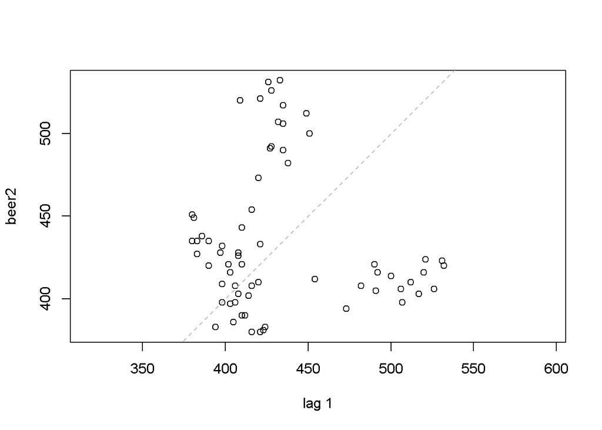

```r
lag.plot(beer2,do.lines=FALSE)
```

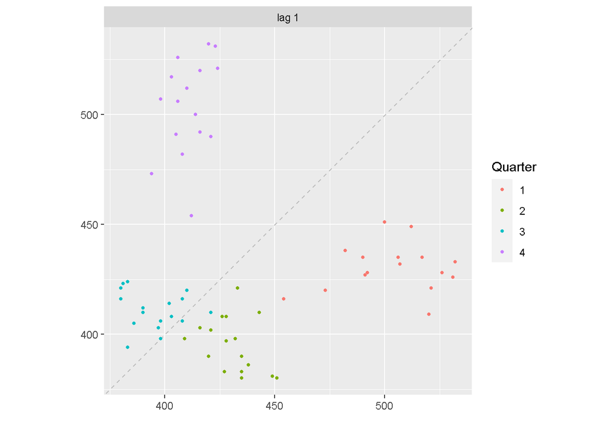

```r
gglagplot(beer2, do.lines=FALSE, lags=1)
```

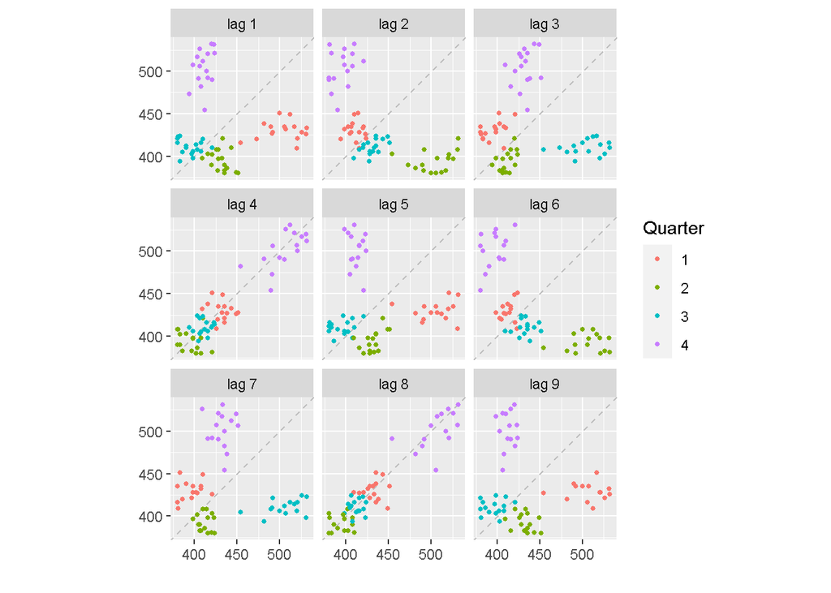

```r
gglagplot(beer2, do.lines=FALSE)
```

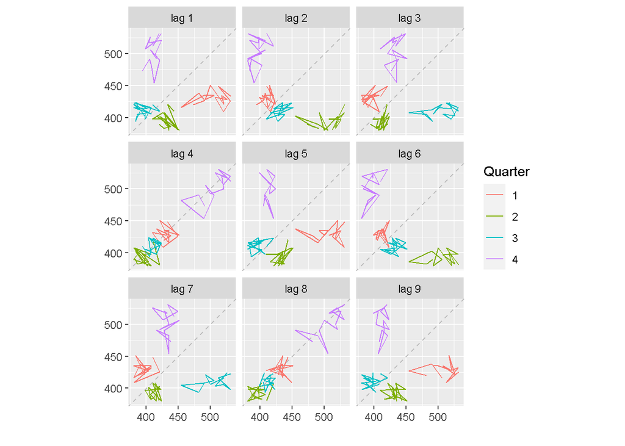

```r
gglagplot(beer2)
```

Here the colours indicate the quarter of the variable on the vertical axis. The lines connect points in chronological order. The relationship is strongly positive at lags 4 and 8, reflecting the strong seasonality in the data. The negative relationship seen for lags 2 and 6 occurs because peaks (in Q4) are plotted against troughs (in Q2)

The window() function used here is very useful when extracting a portion of a time series. In this case, we have extracted the data from ausbeer, beginning in 1992.

```r
ts_lags(USgas)
```

[output not shown]

```r
ts_lags(beer2)
```

[output not shown]

```r
# Seasonal lags plot
ts_lags(USgas, lags = c(12, 24, 36, 48))
```

[output not shown]

### Example1.25(Text book) Sample ACF and Scatter plots

```r
(r = round(acf(soi, 6, plot=FALSE)$acf[-1], 3)) # first 6 sample acf values
```

```
## [1]  0.604  0.374  0.214  0.050 -0.107 -0.187
```

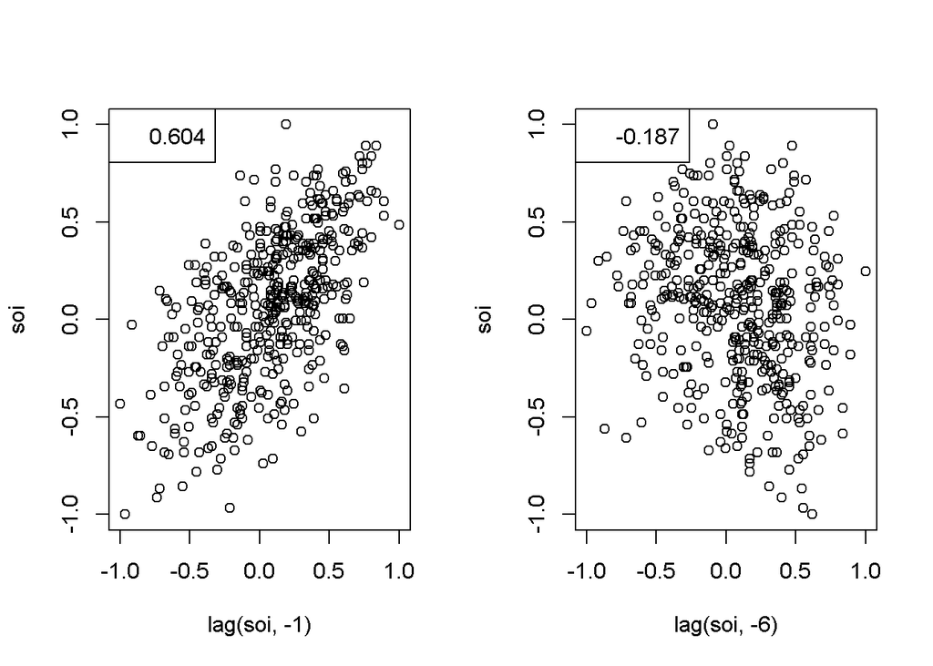

```r
par(mfrow=c(1,2))
plot(lag(soi,-1), soi); legend('topleft', legend=r[1])
plot(lag(soi,-6), soi); legend('topleft', legend=r[6])
```

# 2. Decomposition

Decompose One Time Series into Multiple Series:

Time series decomposition is a mathematical procedure which transforms a time series into multiple different time series. The original time series is often split into 3 component series:

- Seasonal: Patterns that repeat with a fixed period of time. For example, a website might receive more visits during weekends; this would produce data with a seasonality of 7 days.
- Trend: The underlying trend of the metrics. A website increasing in popularity should show a general trend that goes up.
- Random: Also call “noise”, “irregular” or “remainder,” this is the residuals of the original time series after the seasonal and trend series are removed.

# Additive & Multiplicative Decomposition

- Additive: Time Series = Seasonal + Trend + Random
- Multiplicative: Time Series = Seasonal * Trend * Random

# Step-by-step Time Series Decomposition

### Step 1: Import the Data

- Additive

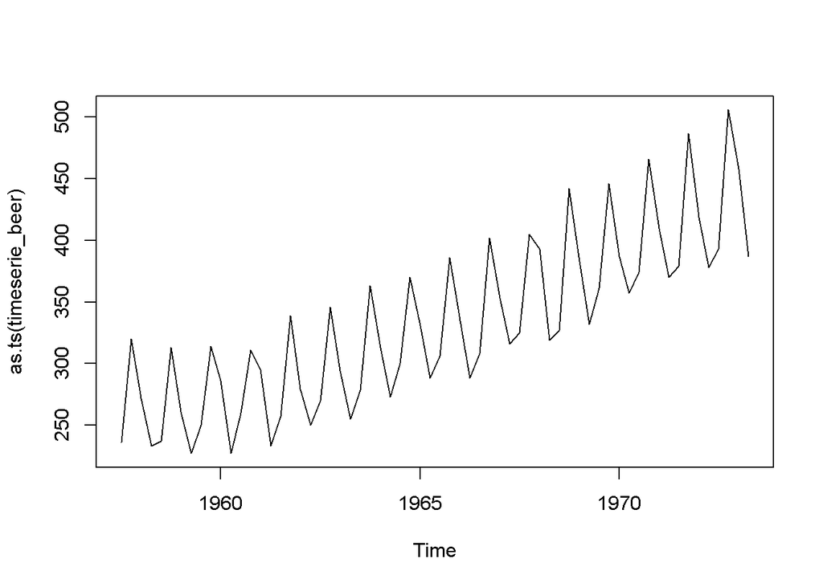

```r
# Additive
# install.packages("fpp")
library(fpp)
data(ausbeer) # This ausbeer dataset is an example of additive time series
timeserie_beer = tail(head(ausbeer, 17*4+2),17*4-4)
plot(as.ts(timeserie_beer)) # As the metric values increase, the seasonality stays relatively constant.
```

- Multiplicative

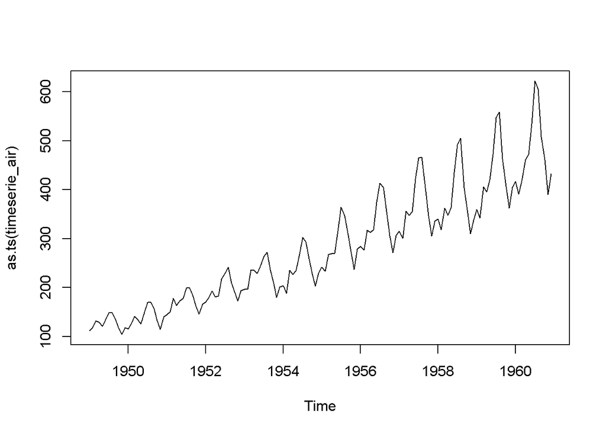

```r
# Multiplicative
# install.packages("Ecdat")
#install.packages("Ecfun")
#library(Ecdat)
#library(Ecfun)

data(AirPassengers) # This AirPassengers dataset is an example of multiplicative time series
timeserie_air = AirPassengers
plot(as.ts(timeserie_air)) # The more passengers there are, the more seasonality is observed.
```

### Step 2: Detect the Trend

- Additive

Australian beer production clearly follows annual seasonality. As it is recorded quarterly, there are 4 data points recorded per year, and we use a moving average window of 4.

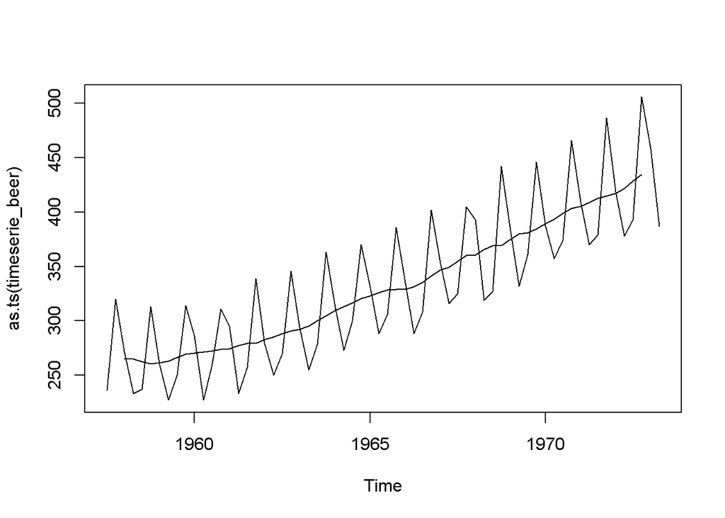

```r
# install.packages("forecast")
library(forecast)
trend_beer = ma(timeserie_beer, order = 4, centre = T)
plot(as.ts(timeserie_beer))
lines(trend_beer)
```

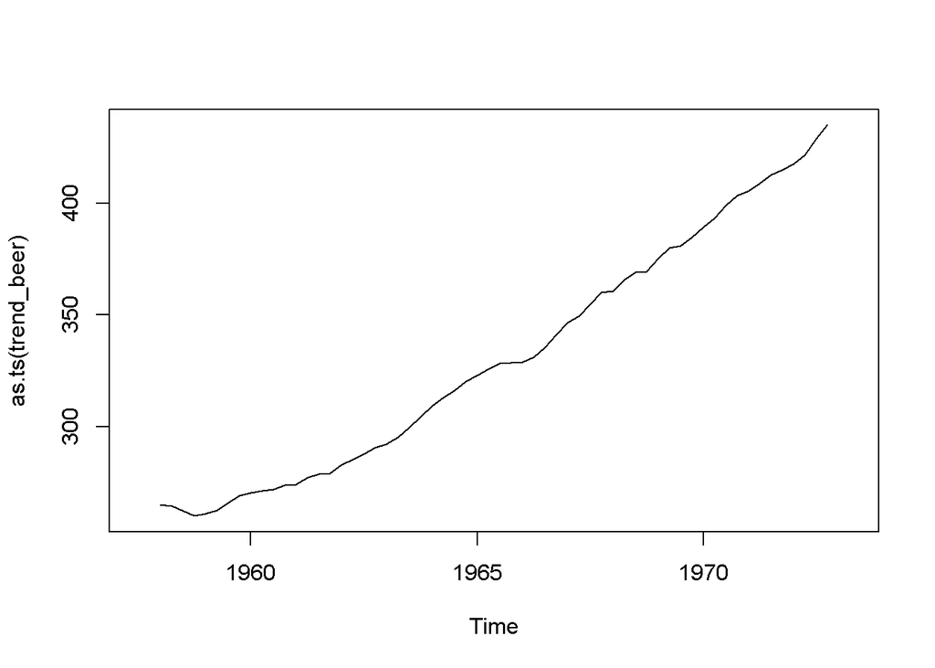

```r
plot(as.ts(trend_beer))
```

- Multiplicative

The process here is the same as for the additive model. Airline passenger number seasonality also looks annual. However, it is recorded monthly, so we choose a moving average window of 12.

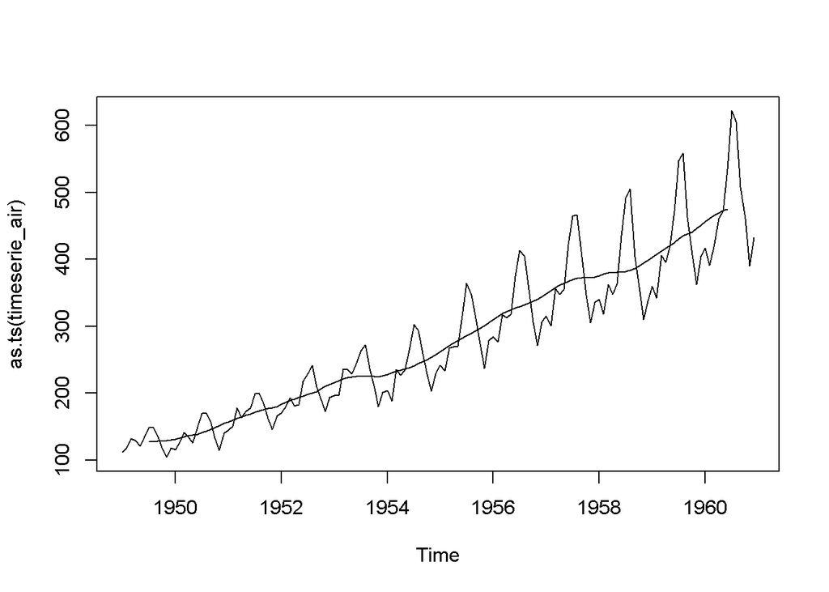

```r
# install.packages("forecast")
library(forecast)
trend_air = ma(timeserie_air, order = 12, centre = T)
plot(as.ts(timeserie_air))
lines(trend_air)
```

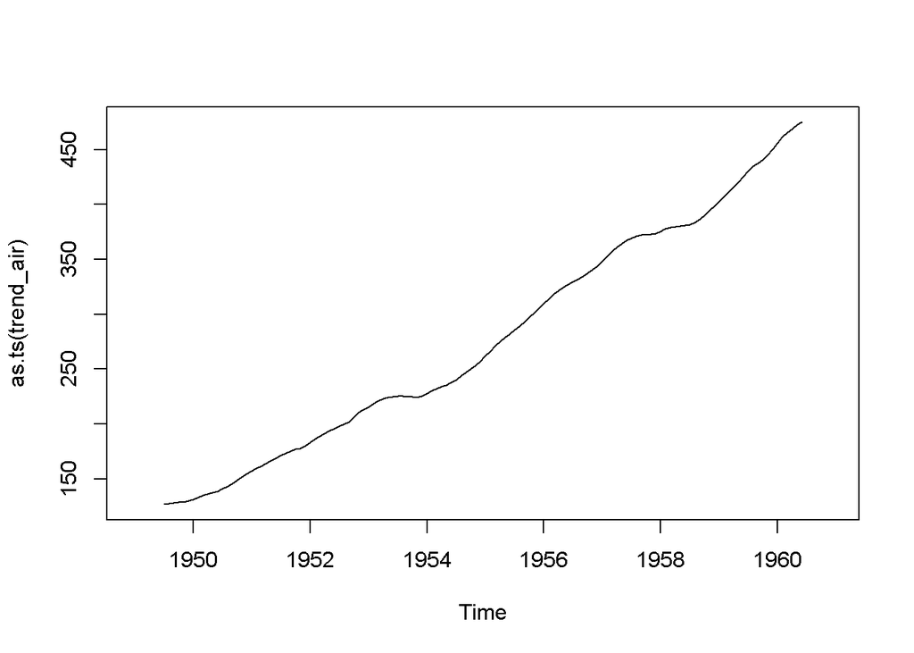

```r
plot(as.ts(trend_air))
```

### Step 3: Detrend the Time Series

Removing the previously calculated trend from the time series will result into a new time series that clearly exposes seasonality

- Additive

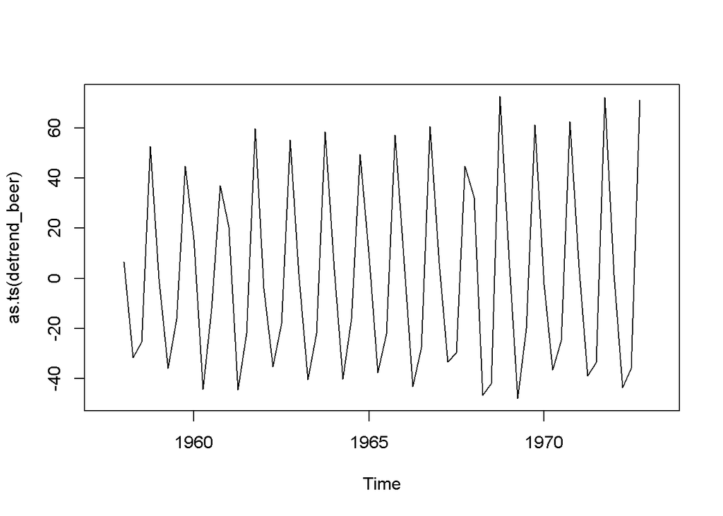

```r
detrend_beer = timeserie_beer - trend_beer
plot(as.ts(detrend_beer))
```

- Multiplicative

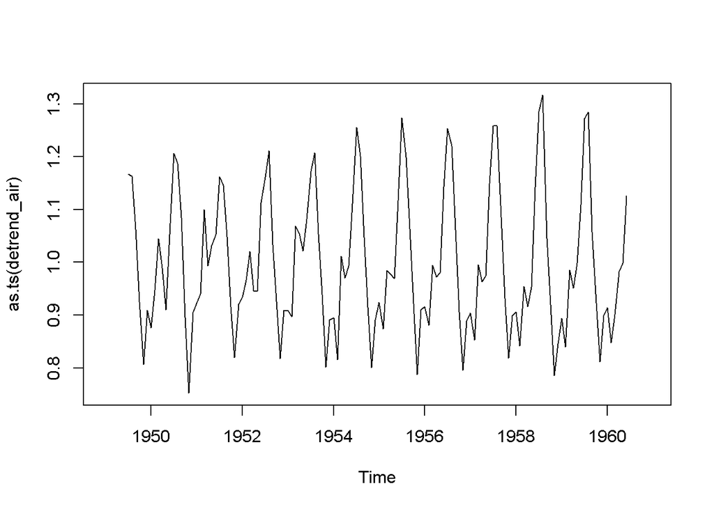

```r
detrend_air = timeserie_air / trend_air
plot(as.ts(detrend_air))
```

### Step 4: Average the Seasonality

From the detrended time series, it’s easy to compute the average seasonality. We add the seasonality together and divide by the seasonality period. Technically speaking, to average together the time series we feed the time series into a matrix. Then, we transform the matrix so each column contains elements of the same period (same day, same month, same quarter, etc…). Finally, we compute the mean of each column. Here is how to do it in R:

- Additive

Quarterly seasonality: we use a matrix of 4 rows. The average seasonality is repeated 16 times to create the graphic to be compared later (see below)

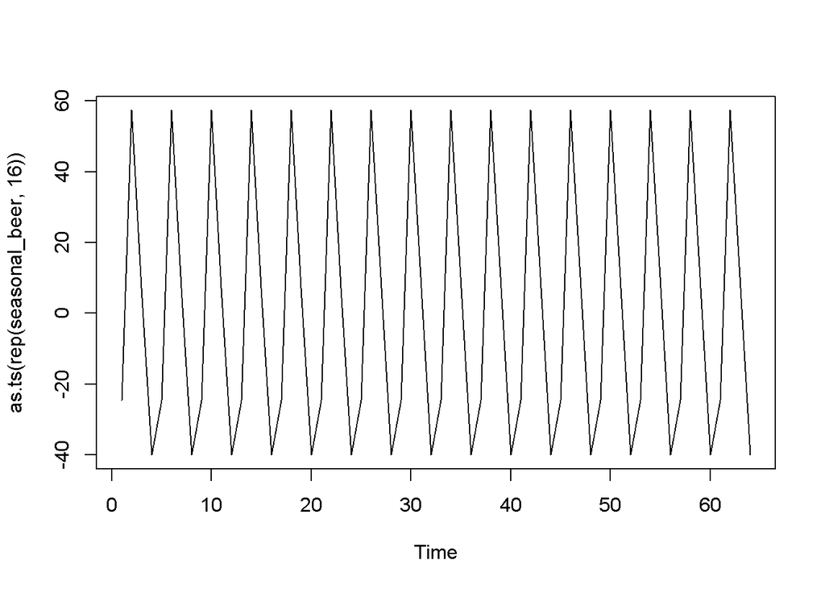

```r
m_beer = t(matrix(data = detrend_beer, nrow = 4))
seasonal_beer = colMeans(m_beer, na.rm = T)
plot(as.ts(rep(seasonal_beer,16)))
```

- Multiplicative

Monthly seasonality: we use a matrix of 12 rows. The average seasonality is repeated 12 times to create the graphic we will compare later (see below)

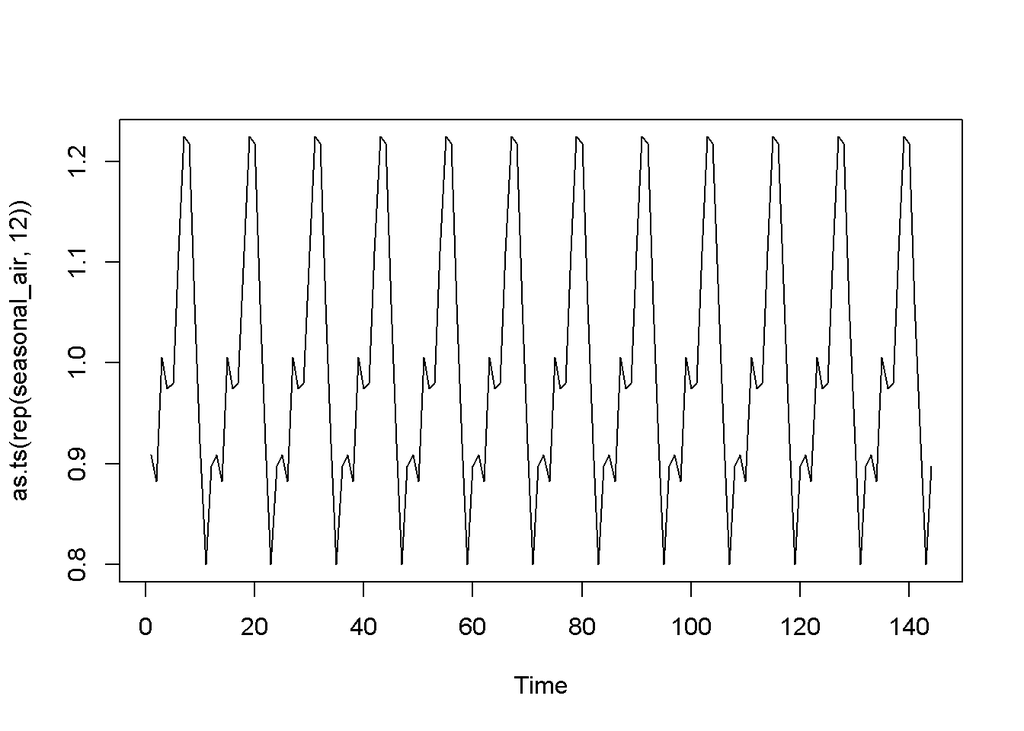

```r
m_air = t(matrix(data = detrend_air, nrow = 12))
seasonal_air = colMeans(m_air, na.rm = T)
plot(as.ts(rep(seasonal_air,12)))
```

### Step 5: Examining Remaining Random Noise

The previous steps have already extracted most of the data from the original time series, leaving behind only “random” noise.

- Additive

The additive formula is “Time series = Seasonal + Trend + Random”, which means “Random = Time series – Seasonal – Trend”

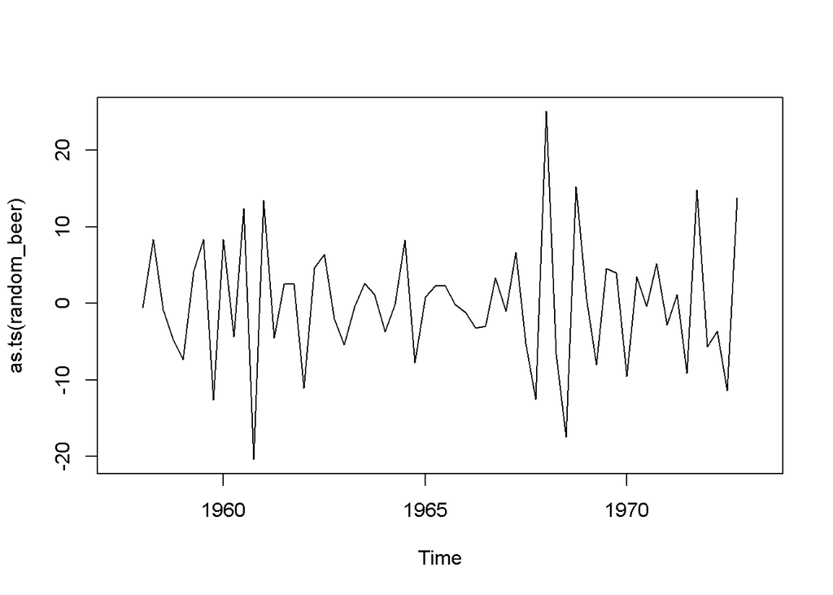

```r
random_beer = timeserie_beer - trend_beer - seasonal_beer
plot(as.ts(random_beer))
```

- Multiplicative

The multiplicative formula is “Time series = Seasonal * Trend * Random”, which means “Random = Time series / (Trend * Seasonal)”

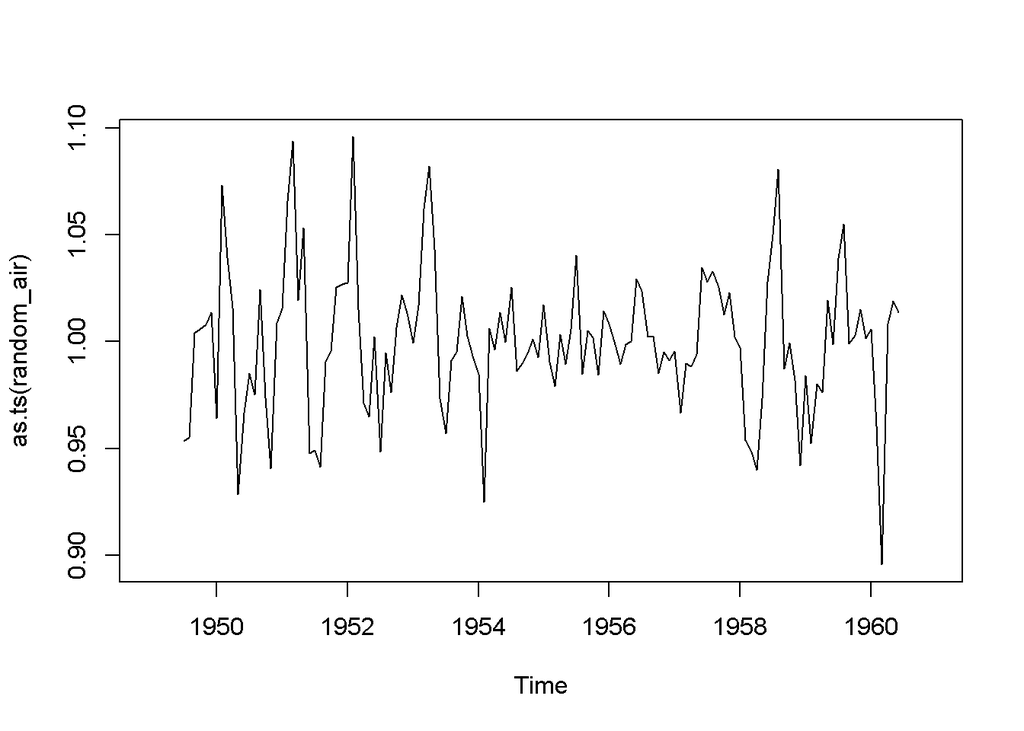

```r
random_air = timeserie_air / (trend_air * seasonal_air)
plot(as.ts(random_air))
```

### Step 6: Reconstruct the Original Signal

The decomposed time series can logically be recomposed using the model formula to reproduce the original signal. Some data points will be missing at the beginning and the end of the reconstructed time series, due to the moving average windows which must consume some data before producing average data points.

- Additive

The additive formula is “Time series = Seasonal + Trend + Random”, which means “Random = Time series – Seasonal – Trend”

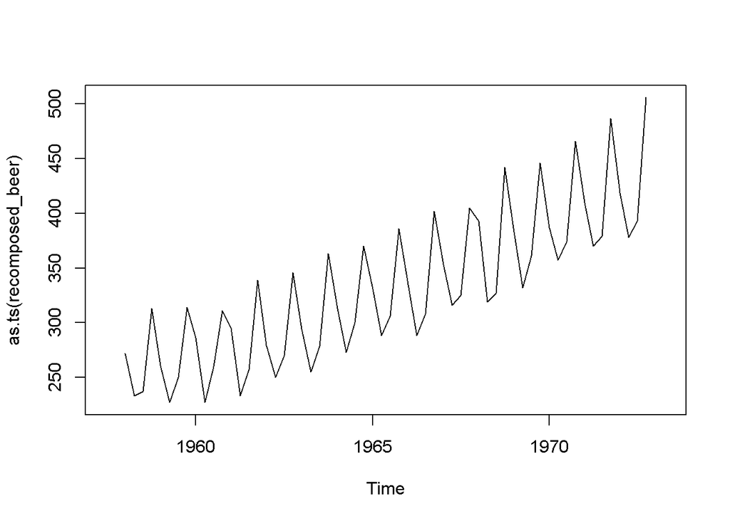

```r
recomposed_beer = trend_beer+seasonal_beer+random_beer
plot(as.ts(recomposed_beer))
```

- Multiplicative

The multiplicative formula is “Time series = Seasonal * Trend * Random”, which means “Random = Time series / (Trend * Seasonal)”

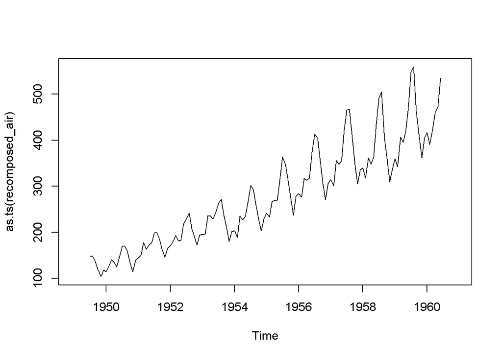

```r
recomposed_air = trend_air*seasonal_air*random_air
plot(as.ts(recomposed_air))
```

# DECOMPOSE( ) and STL(): Time Series Decomposition in R

To make life easier, some R packages provides decomposition with a single line of code. As expected, our step-by-step decomposition provides the same results as the DECOMPOSE( ) and STL( ) functions (see the graphs).

### Decompose() function

- Additive

The only requirement: seasonality is quarterly (frequency = 4)

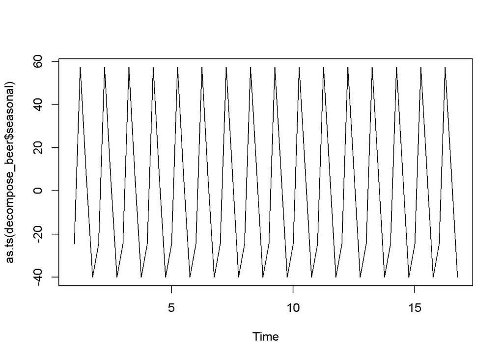

```r
ts_beer = ts(timeserie_beer, frequency = 4)
decompose_beer = decompose(ts_beer, "additive")

plot(as.ts(decompose_beer$seasonal))
```

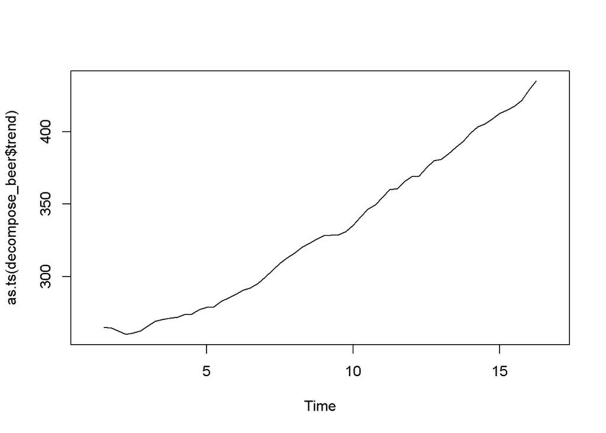

```r
plot(as.ts(decompose_beer$trend))
```

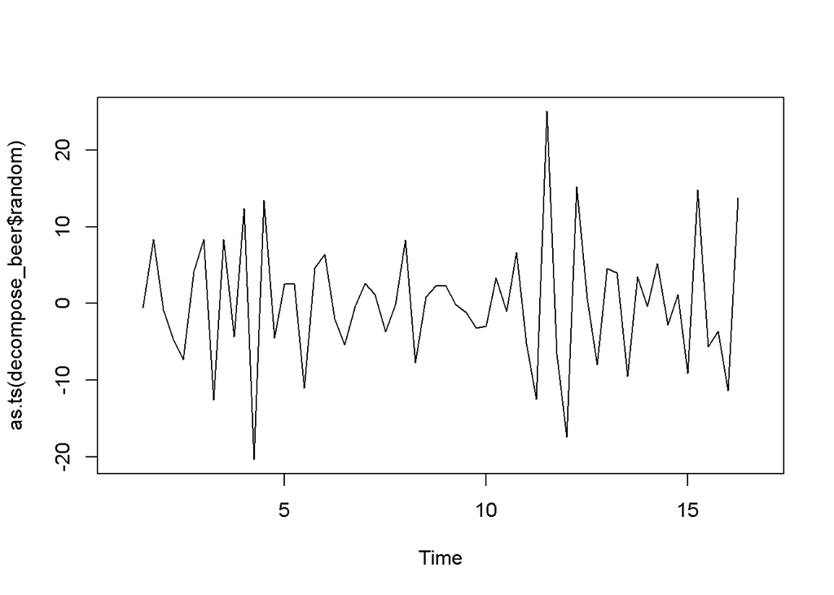

```r
plot(as.ts(decompose_beer$random))
```

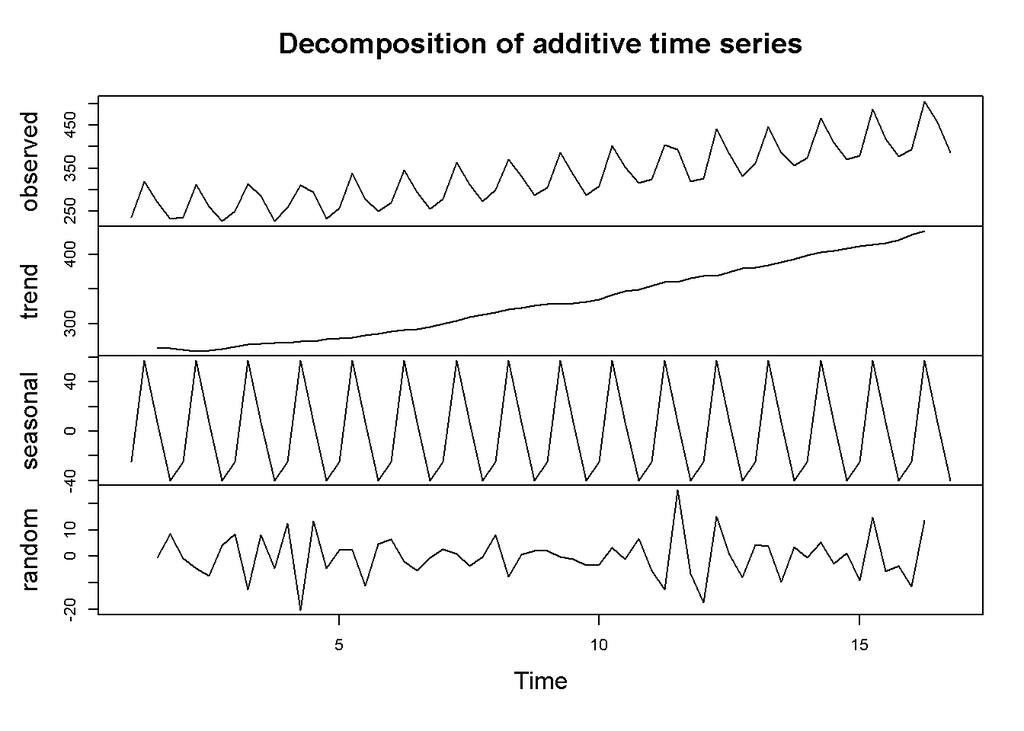

```r
plot(decompose_beer)
```

- Multiplicative

The only requirement: seasonality is monthly (frequency = 12)

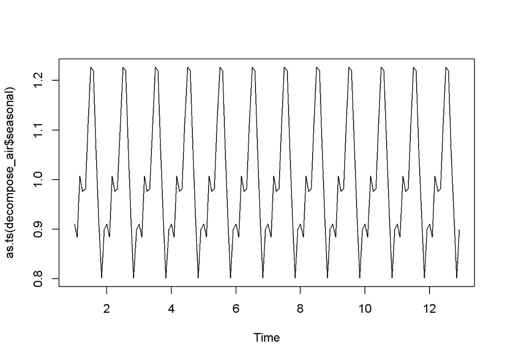

```r
ts_air = ts(timeserie_air, frequency = 12)
decompose_air = decompose(ts_air, "multiplicative")

plot(as.ts(decompose_air$seasonal))
```

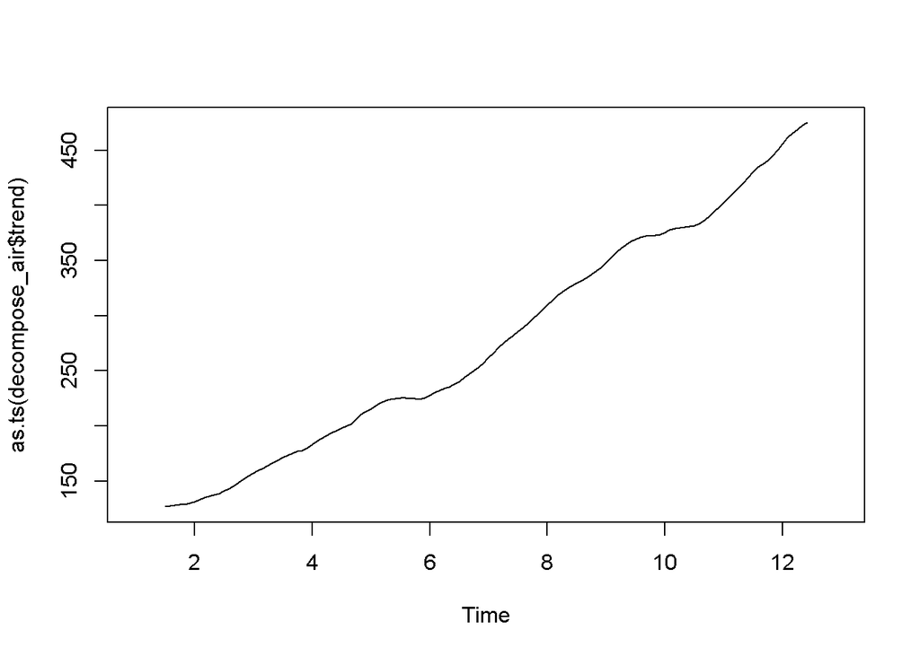

```r
plot(as.ts(decompose_air$trend))
```

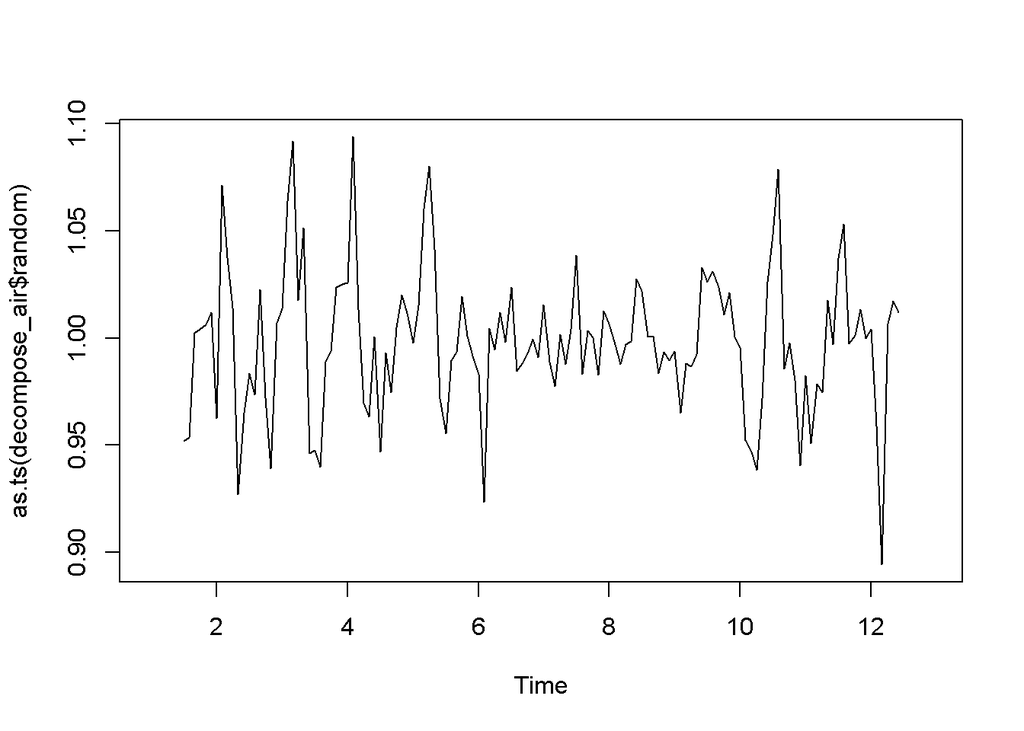

```r
plot(as.ts(decompose_air$random))
```

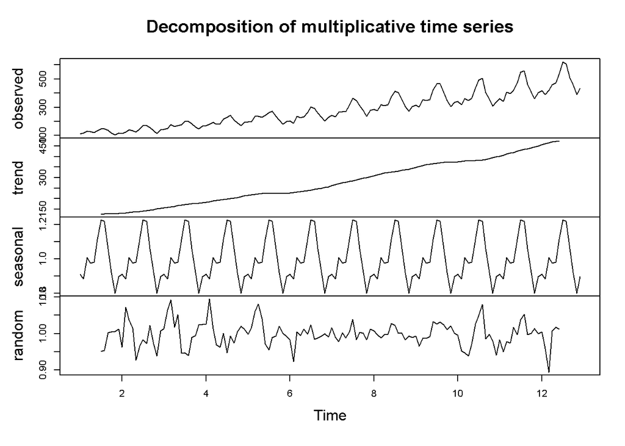

```r
plot(decompose_air)
```

### Now using the STL( ) function:

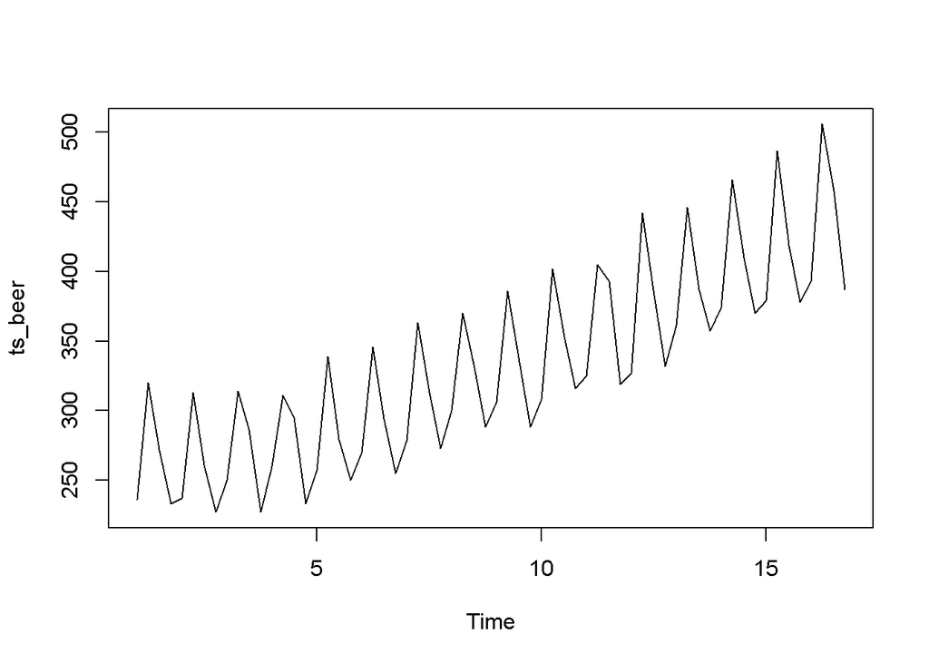

```r
ts_beer = ts(timeserie_beer, frequency = 4)
stl_beer = stl(ts_beer, "periodic")
seasonal_stl_beer   <- stl_beer$time.series[,1]
trend_stl_beer     <- stl_beer$time.series[,2]
random_stl_beer  <- stl_beer$time.series[,3]

plot(ts_beer)
```

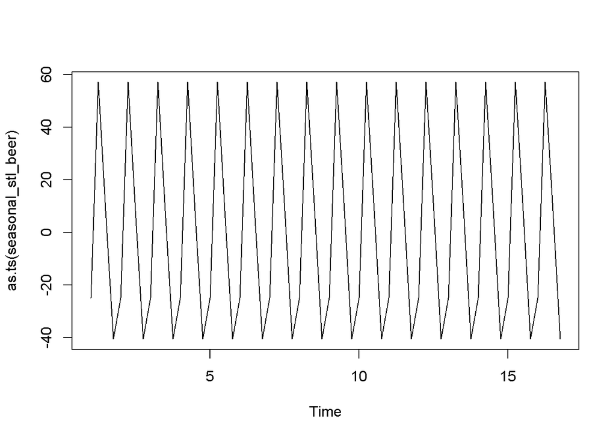

```r
plot(as.ts(seasonal_stl_beer))
```

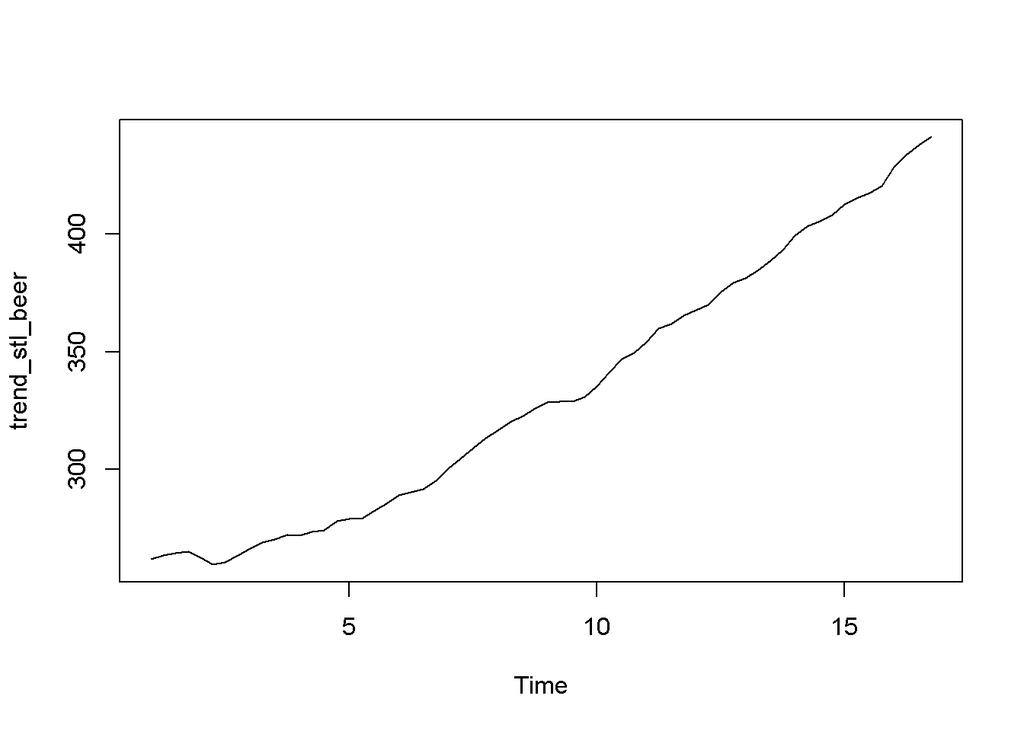

```r
plot(trend_stl_beer)
```

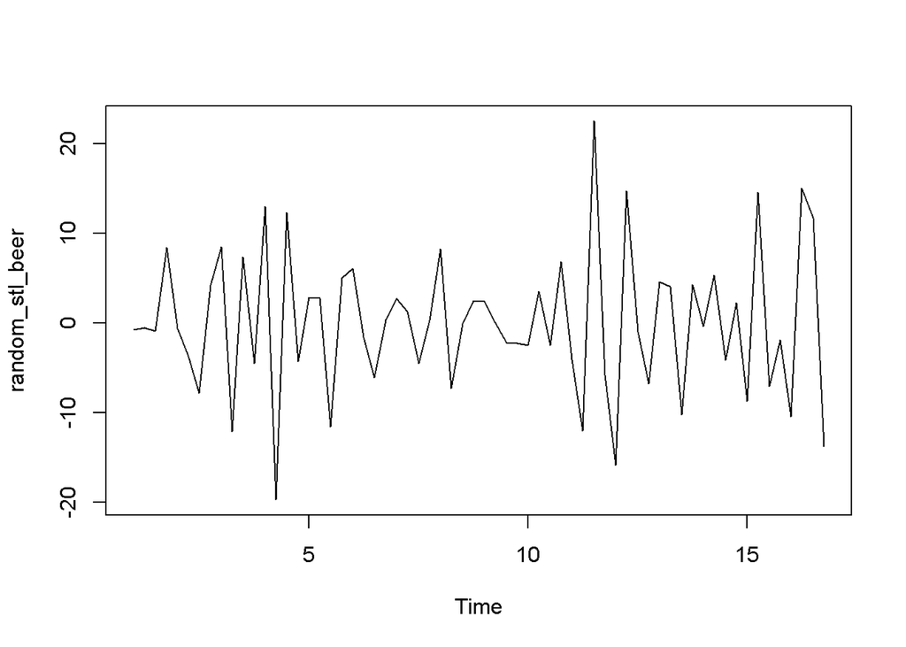

```r
plot(random_stl_beer)
```

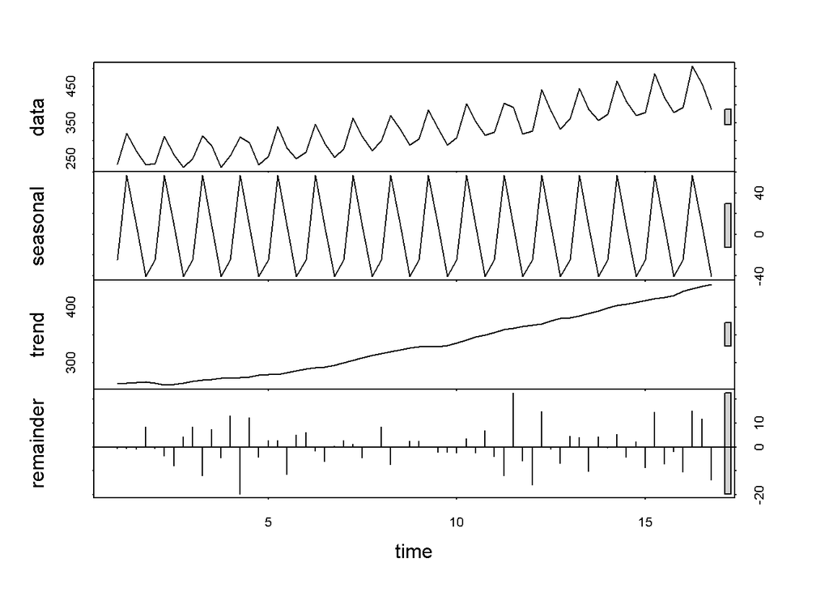

```r
plot(stl_beer)
```